# Data Journalism Assignment 2 - Airline Delays

Mike Peleah

2024-01-01

## Description

This is an open-ended assignment requiring your critical thinking skills. Be ready to explore, experiment, and program on your own! You can visualize the flight delay data with maps, bar charts, line charts, scatterplots, and many others. Some guidance questions include: - Which airline should you fly on to avoid significant delays? - Which months should you fly on to avoid significant delays? - Any relationships between seasons and flight delays? - Which region of airport has the most significant number of delays? - What is the major reasons for delay?

Delays can be categorized into: - **Air carrier**, where the cause was within the airline’s control (e.g., maintenance or crew problems, aircraft cleaning, baggage loading, fueling, etc.). - **Extreme weather** such as tornadoes, blizzards, or hurricanes. - **National Aviation System (NAS)**, which refers to a broad set of conditions, such as non-extreme weather conditions, airport operations, heavy traffic volume, and air traffic control. - **Late-arriving aircraft**, where a previous flight with same aircraft arrived late, causing the present flight to depart late. - **Security**, caused by evacuation of a terminal or concourse, re-boarding of aircraft because of a security breach, inoperative screening equipment, and/or long lines in excess of 29 minutes at screening areas.

### Note on methodology and data

Dataset—Airline Delay Causes-is provided with a data file consisting of on-time statistics for airlines in the United States. This data set is freely available from The US Department of Transportation at http://www.transtats.bts.gov/OT_Delay/OT_DelayCause1.asp A copy of the data containing entries ranging from February, 2009 to February, 2019 was provided in data/assignment-airlinedelay.csv. List of airport codes with coordinates from [DataHub](https://datahub.io/core/airport-codes).

Assignment instruction suggested using Python/Plotly library, or any other. Hence I decided to use R+ggplot, as I have better command of this technology. I used RMarkdown to knit into HTML file.

Code and all all files are available online in GitHub repo https://github.com/MikePeleah/Learning-Bits-n-Pieces/tree/main/Coursera%20Data%20Journalism

### First look on dataset

```
## [1] 155692
```

```
##       year          month          carrier          carrier_name
##  Min.   :2009   Min.   : 1.000   Length:155692      Length:155692
##  1st Qu.:2011   1st Qu.: 3.000   Class :character   Class :character
##  Median :2013   Median : 6.000   Mode  :character   Mode  :character
##  Mean   :2014   Mean   : 6.454
##  3rd Qu.:2016   3rd Qu.: 9.000
##  Max.   :2019   Max.   :12.000
##
##    airport          airport_name        arr_flights        arr_del15
##  Length:155692      Length:155692      Min.   :    1.0   Min.   :   0.00
##  Class :character   Class :character   1st Qu.:   59.0   1st Qu.:   9.00
##  Mode  :character   Mode  :character   Median :  122.0   Median :  23.00
##                                        Mean   :  399.8   Mean   :  74.31
##                                        3rd Qu.:  289.0   3rd Qu.:  56.00
##                                        Max.   :21977.0   Max.   :5268.00
##                                        NA's   :193       NA's   :228
##    carrier_ct        weather_ct          nas_ct         security_ct
##  Min.   :   0.00   Min.   :  0.000   Min.   :   0.00   Min.   : 0.000
##  1st Qu.:   3.05   1st Qu.:  0.000   1st Qu.:   1.94   1st Qu.: 0.000
##  Median :   8.02   Median :  0.470   Median :   5.56   Median : 0.000
##  Mean   :  21.13   Mean   :  2.273   Mean   :  23.51   Mean   : 0.141
##  3rd Qu.:  19.45   3rd Qu.:  1.910   3rd Qu.:  15.12   3rd Qu.: 0.000
##  Max.   :1242.16   Max.   :298.620   Max.   :2401.79   Max.   :19.530
##  NA's   :193       NA's   :193       NA's   :193       NA's   :193
##  late_aircraft_ct  arr_cancelled       arr_diverted        arr_delay
##  Min.   :   0.00   Min.   :   0.000   Min.   :  0.0000   Min.   :     0
##  1st Qu.:   2.10   1st Qu.:   0.000   1st Qu.:  0.0000   1st Qu.:   458
##  Median :   6.74   Median :   1.000   Median :  0.0000   Median :  1221
##  Mean   :  27.24   Mean   :   6.399   Mean   :  0.9474   Mean   :  4346
##  3rd Qu.:  18.46   3rd Qu.:   4.000   3rd Qu.:  1.0000   3rd Qu.:  3172
##  Max.   :1885.47   Max.   :1389.000   Max.   :256.0000   Max.   :429194
##  NA's   :193       NA's   :193        NA's   :193        NA's   :193
##  carrier_delay    weather_delay       nas_delay      security_delay
##  Min.   :     0   Min.   :    0.0   Min.   :     0   Min.   :   0.000
##  1st Qu.:   153   1st Qu.:    0.0   1st Qu.:    64   1st Qu.:   0.000
##  Median :   441   Median :   21.0   Median :   205   Median :   0.000
##  Mean   :  1327   Mean   :  199.1   Mean   :  1075   Mean   :   5.872
##  3rd Qu.:  1138   3rd Qu.:  145.0   3rd Qu.:   592   3rd Qu.:   0.000
##  Max.   :196944   Max.   :31960.0   Max.   :137443   Max.   :3194.000
##  NA's   :193      NA's   :193       NA's   :193      NA's   :193
##  late_aircraft_delay
##  Min.   :     0
##  1st Qu.:   112
##  Median :   411
##  Mean   :  1738
##  3rd Qu.:  1203
##  Max.   :148181
##  NA's   :193
```

| carrier_name | nflights | ndelays | pdelay |
| --- | --- | --- | --- |
| Comair Inc. | 286694 | 70523 | 24.59870 |
| JetBlue Airways | 2516031 | 588969 | 23.40865 |
| Frontier Airlines Inc. | 914997 | 212071 | 23.17723 |
| Allegiant Air | 110255 | 24651 | 22.35817 |
| Envoy Air | 932356 | 205151 | 22.00351 |
| Atlantic Southeast Airlines | 923459 | 202075 | 21.88240 |
| Spirit Air Lines | 617450 | 133954 | 21.69471 |
| ExpressJet Airlines Inc. | 4891450 | 1028741 | 21.03141 |
| Virgin America | 389060 | 79576 | 20.45340 |
| American Eagle Airlines Inc. | 2300220 | 459897 | 19.99361 |

| carrier_name | nflights | ndelays | pdelay |
| --- | --- | --- | --- |
| Hawaiian Airlines Inc. | 744710 | 64404 | 8.648199 |
| Alaska Airlines Inc. | 1689757 | 229675 | 13.592191 |
| Delta Air Lines Inc. | 7951811 | 1187260 | 14.930687 |
| US Airways Inc. | 2624022 | 436809 | 16.646545 |
| AirTran Airways Corporation | 1201121 | 202733 | 16.878649 |
| Endeavor Air Inc. | 404370 | 68852 | 17.026980 |
| Mesa Airlines Inc. | 1080705 | 184206 | 17.044985 |
| Pinnacle Airlines Inc. | 678801 | 117448 | 17.302273 |
| SkyWest Airlines Inc. | 6346724 | 1142653 | 18.003824 |
| Republic Airline | 365631 | 67283 | 18.401886 |

| airport_name | nflights | ndelays | pdelay |
| --- | --- | --- | --- |
| Topeka, KS: Topeka Regional | 449 | 164 | 36.52561 |
| Stockton, CA: Stockton Metropolitan | 104 | 35 | 33.65385 |
| Wilmington, DE: New Castle | 1157 | 376 | 32.49784 |
| St. Cloud, MN: St. Cloud Regional | 733 | 236 | 32.19645 |
| Owensboro, KY: Owensboro Daviess County Regional | 127 | 39 | 30.70866 |
| Crescent City, CA: Jack McNamara Field | 6136 | 1861 | 30.32920 |
| Sanford, FL: Orlando Sanford International | 11100 | 3315 | 29.86486 |
| North Bend/Coos Bay, OR: Southwest Oregon Regional | 6892 | 2053 | 29.78816 |
| Stockton, CA: Stockton Metro | 747 | 216 | 28.91566 |
| Greenville, NC: Pitt Greenville | 896 | 259 | 28.90625 |

| airport_name | nflights | ndelays | pdelay |
| --- | --- | --- | --- |
| Moses Lake, WA: Grant County International | 675 | 37 | 5.481481 |
| Lewiston, ID: Lewiston Nez Perce County | 6915 | 448 | 6.478670 |
| Butte, MT: Bert Mooney | 7220 | 492 | 6.814404 |
| Telluride, CO: Telluride Regional | 468 | 32 | 6.837607 |
| Oxnard/Ventura, CA: Oxnard | 1526 | 117 | 7.667104 |
| Hilo, HI: Hilo International | 67978 | 5251 | 7.724558 |
| West Yellowstone, MT: Yellowstone | 2531 | 212 | 8.376136 |
| Moab, UT: Canyonlands Field | 827 | 71 | 8.585248 |
| Tunica, MS: Tunica Municipal | 208 | 18 | 8.653846 |
| Inyokern, CA: Inyokern Airport | 4080 | 363 | 8.897059 |

### Let’s explore if big airports and companies are more prone to delays

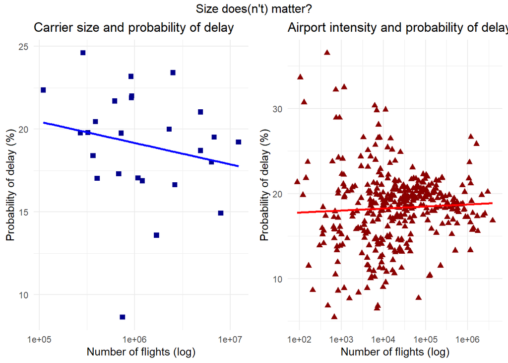

#### Let’s explore causes of delay:

| cause | avg_delay | median_delay | min_delay | max_delay |
| --- | --- | --- | --- | --- |
| Total delay | 55.63031 | 52.57417 | 15.00000 | 1461.000 |
| Carriers | 58.67621 | 52.53790 | 14.28571 | 1461.000 |
| Weather | 85.01897 | 68.70748 | 14.28571 | 2475.000 |
| Natl Air Service | 41.02617 | 36.09467 | 14.28571 | 1200.000 |
| Security | 44.25158 | 31.03448 | 14.28571 | 1061.290 |
| Aircraft delayed in the previous flight | 63.07028 | 59.34959 | 14.28571 | 1239.189 |

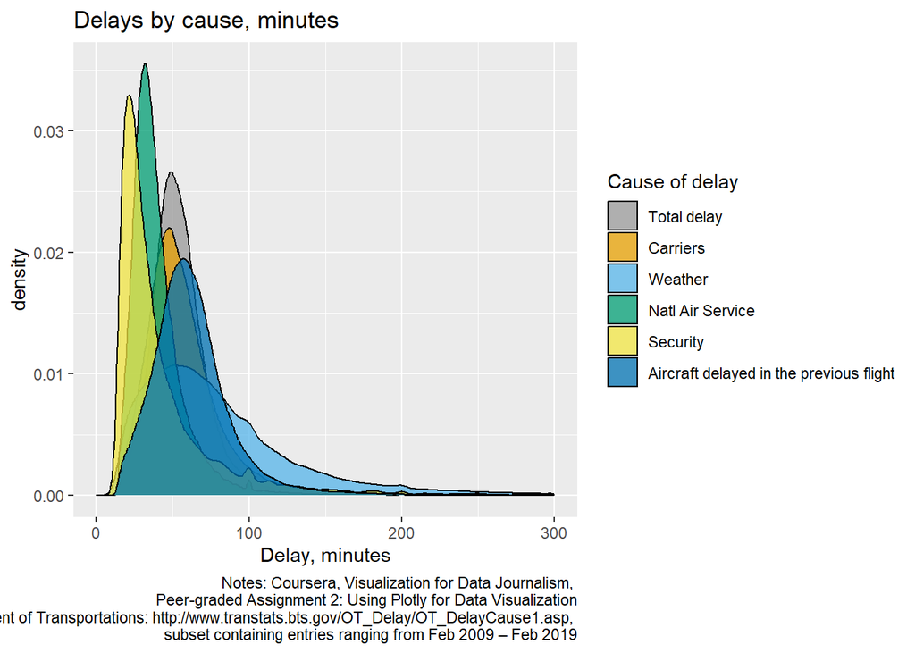

### Let’s look in details by airports and companies

The major cause of delay during the data period was an Aircraft delayed in the previous flight (36.7%) followed by Natl Air Service (31.6%) and Carriers (28.4%). Weather (3%) and Security (less 1%) were minor cuases.

| stat | Country average |
| --- | --- |
| Probability of delay (%), by cause | 18.5822791 |
| .. Carriers | 28.4367089 |
| .. Weather | 3.0587759 |
| .. Natl Air Service | 31.6457085 |
| .. Security | 0.1897666 |
| .. Aircraft delayed in the previous flight | 36.6691338 |

Let’s look on carriers in more details

| carrier_name | pdelay | sh_carrier | sh_weather | sh_nas | sh_security | sh_late_aircraft |
| --- | --- | --- | --- | --- | --- | --- |
| Comair Inc. | 24.59870 | 32.84880 | 10.973796 | 47.03158 | 0.09460743 | 9.051373 |
| JetBlue Airways | 23.40865 | 31.11066 | 1.653056 | 33.12154 | 0.29549263 | 33.819313 |
| Frontier Airlines Inc. | 23.17723 | 24.20142 | 1.169099 | 40.19890 | 0.00000000 | 34.430243 |
| Allegiant Air | 22.35817 | 28.57276 | 5.062634 | 24.27922 | 0.48440226 | 41.602978 |
| Envoy Air | 22.00351 | 23.07439 | 5.797028 | 34.46554 | 0.19899001 | 36.464156 |
| Atlantic Southeast Airlines | 21.88240 | 28.71497 | 2.776959 | 27.68980 | 0.08577508 | 40.733020 |
| Spirit Air Lines | 21.69471 | 18.90765 | 1.801066 | 56.96376 | 0.36574496 | 21.961517 |
| ExpressJet Airlines Inc. | 21.03141 | 27.26040 | 1.924013 | 31.86175 | 0.09202705 | 38.861954 |
| Virgin America | 20.45340 | 19.29119 | 8.658880 | 38.72910 | 0.42400975 | 32.897130 |
| American Eagle Airlines Inc. | 19.99361 | 25.61883 | 6.103064 | 31.80460 | 0.04682570 | 36.426780 |

| carrier_name | pdelay | sh_carrier | sh_weather | sh_nas | sh_security | sh_late_aircraft |
| --- | --- | --- | --- | --- | --- | --- |
| Hawaiian Airlines Inc. | 8.648199 | 60.91539 | 2.413903 | 2.148329 | 0.29560276 | 34.22700 |
| Alaska Airlines Inc. | 13.592191 | 24.73917 | 2.353273 | 44.831806 | 0.57194296 | 27.50393 |
| Delta Air Lines Inc. | 14.930687 | 31.32701 | 3.917667 | 36.925435 | 0.05795866 | 27.77201 |
| US Airways Inc. | 16.646545 | 28.26005 | 1.881903 | 45.818964 | 0.41947854 | 23.61982 |
| AirTran Airways Corporation | 16.878649 | 20.43335 | 1.042021 | 37.549131 | 0.00000000 | 40.97556 |
| Endeavor Air Inc. | 17.026980 | 25.34317 | 3.509818 | 34.992665 | 0.06949689 | 36.08465 |
| Mesa Airlines Inc. | 17.044985 | 37.19916 | 4.854543 | 26.773726 | 0.37058511 | 30.80203 |
| Pinnacle Airlines Inc. | 17.302273 | 29.72043 | 3.189360 | 37.903234 | 0.14393604 | 29.04322 |
| SkyWest Airlines Inc. | 18.003824 | 23.01147 | 2.525757 | 30.186589 | 0.14934893 | 44.12705 |
| Republic Airline | 18.401886 | 19.85726 | 3.096310 | 44.626919 | 0.09002274 | 32.32979 |

| carrier_name | pdelay | sh_carrier | sh_weather | sh_nas | sh_security | sh_late_aircraft |
| --- | --- | --- | --- | --- | --- | --- |
| Hawaiian Airlines Inc. | 8.648199 | 60.91539 | 2.413903 | 2.148329 | 0.29560276 | 34.227005 |
| Mesa Airlines Inc. | 17.044985 | 37.19916 | 4.854543 | 26.773726 | 0.37058511 | 30.802031 |
| Comair Inc. | 24.598701 | 32.84880 | 10.973796 | 47.031578 | 0.09460743 | 9.051373 |
| Delta Air Lines Inc. | 14.930687 | 31.32701 | 3.917667 | 36.925435 | 0.05795866 | 27.772011 |
| JetBlue Airways | 23.408654 | 31.11066 | 1.653056 | 33.121536 | 0.29549263 | 33.819313 |
| American Airlines Inc. | 19.521160 | 30.95351 | 4.034213 | 33.776145 | 0.17029489 | 31.065857 |
| Northwest Airlines Inc. | 19.761795 | 30.58711 | 4.947354 | 43.207458 | 0.21313256 | 21.045342 |
| Southwest Airlines Co. | 19.218380 | 29.80943 | 2.374315 | 18.156613 | 0.28470750 | 49.374965 |
| Pinnacle Airlines Inc. | 17.302273 | 29.72043 | 3.189360 | 37.903234 | 0.14393604 | 29.043219 |
| United Air Lines Inc. | 18.703106 | 28.91711 | 3.047569 | 36.422220 | 0.04945717 | 31.563750 |

| carrier_name | pdelay | sh_carrier | sh_weather | sh_nas | sh_security | sh_late_aircraft |
| --- | --- | --- | --- | --- | --- | --- |
| Southwest Airlines Co. | 19.21838 | 29.80943 | 2.374315 | 18.15661 | 0.28470750 | 49.37496 |
| SkyWest Airlines Inc. | 18.00382 | 23.01147 | 2.525757 | 30.18659 | 0.14934893 | 44.12705 |
| PSA Airlines Inc. | 19.79040 | 27.71377 | 4.920442 | 24.29058 | 0.19299041 | 42.88180 |
| Allegiant Air | 22.35817 | 28.57276 | 5.062634 | 24.27922 | 0.48440226 | 41.60298 |
| AirTran Airways Corporation | 16.87865 | 20.43335 | 1.042021 | 37.54913 | 0.00000000 | 40.97556 |
| Atlantic Southeast Airlines | 21.88240 | 28.71497 | 2.776959 | 27.68980 | 0.08577508 | 40.73302 |
| ExpressJet Airlines Inc. | 21.03141 | 27.26040 | 1.924013 | 31.86175 | 0.09202705 | 38.86195 |
| Envoy Air | 22.00351 | 23.07439 | 5.797028 | 34.46554 | 0.19899001 | 36.46416 |
| American Eagle Airlines Inc. | 19.99361 | 25.61883 | 6.103064 | 31.80460 | 0.04682570 | 36.42678 |
| Endeavor Air Inc. | 17.02698 | 25.34317 | 3.509818 | 34.99267 | 0.06949689 | 36.08465 |

| airport_name | pdelay | sh_carrier | sh_weather | sh_nas | sh_security | sh_late_aircraft |
| --- | --- | --- | --- | --- | --- | --- |
| Topeka, KS: Topeka Regional | 36.52561 | 25.55488 | 1.0365854 | 26.11585 | 0.00000000 | 47.28049 |
| Stockton, CA: Stockton Metropolitan | 33.65385 | 30.22857 | 1.0285714 | 33.45714 | 0.00000000 | 35.25714 |
| Wilmington, DE: New Castle | 32.49784 | 20.04787 | 0.5904255 | 46.30053 | 0.00000000 | 33.05585 |
| St. Cloud, MN: St. Cloud Regional | 32.19645 | 27.52542 | 2.4237288 | 20.38983 | 0.00000000 | 49.65678 |
| Owensboro, KY: Owensboro Daviess County Regional | 30.70866 | 28.51282 | 0.0000000 | 26.17949 | 0.00000000 | 45.28205 |
| Crescent City, CA: Jack McNamara Field | 30.32920 | 17.72918 | 2.7178936 | 13.12198 | 0.10585707 | 66.32617 |
| Sanford, FL: Orlando Sanford International | 29.86486 | 25.35143 | 3.8217195 | 22.13514 | 0.57134238 | 48.11946 |
| North Bend/Coos Bay, OR: Southwest Oregon Regional | 29.78816 | 21.77204 | 1.7515830 | 16.75402 | 0.01850950 | 59.71164 |
| Stockton, CA: Stockton Metro | 28.91566 | 28.51389 | 3.4027778 | 24.80093 | 0.41666667 | 42.85648 |
| Greenville, NC: Pitt Greenville | 28.90625 | 37.70656 | 7.4594595 | 15.83784 | 0.02316602 | 38.98456 |

| airport_name | pdelay | sh_carrier | sh_weather | sh_nas | sh_security | sh_late_aircraft |
| --- | --- | --- | --- | --- | --- | --- |
| Moses Lake, WA: Grant County International | 5.481481 | 13.08108 | 4.3513514 | 2.513514 | 0.00000000 | 80.08108 |
| Lewiston, ID: Lewiston Nez Perce County | 6.478670 | 38.96652 | 3.5379464 | 42.064732 | 0.06919643 | 15.37723 |
| Butte, MT: Bert Mooney | 6.814404 | 35.18902 | 9.6158537 | 39.327236 | 0.07113821 | 15.80285 |
| Telluride, CO: Telluride Regional | 6.837607 | 58.37500 | 8.8437500 | 23.750000 | 0.00000000 | 9.03125 |
| Oxnard/Ventura, CA: Oxnard | 7.667104 | 25.33333 | 0.4700855 | 21.435897 | 0.00000000 | 52.75214 |
| Hilo, HI: Hilo International | 7.724558 | 50.20872 | 1.9253476 | 11.349838 | 0.26966292 | 36.24643 |
| West Yellowstone, MT: Yellowstone | 8.376136 | 44.64151 | 1.5047170 | 38.566038 | 0.47169811 | 14.82075 |
| Moab, UT: Canyonlands Field | 8.585248 | 41.19718 | 9.0422535 | 31.140845 | 0.00000000 | 18.64789 |
| Tunica, MS: Tunica Municipal | 8.653846 | 29.94444 | 5.5555556 | 53.722222 | 0.00000000 | 10.77778 |
| Inyokern, CA: Inyokern Airport | 8.897059 | 33.56474 | 1.0468320 | 12.170799 | 0.00000000 | 53.22039 |

| airport_name | pdelay | sh_carrier | sh_weather | sh_nas | sh_security | sh_late_aircraft |
| --- | --- | --- | --- | --- | --- | --- |
| Kodiak, AK: Kodiak Airport | 10.20408 | 33.36984 | 19.62063 | 28.42222 | 0.1587302 | 18.423810 |
| Watertown, NY: Watertown International | 20.36173 | 22.45845 | 18.12321 | 30.55014 | 0.0000000 | 28.859599 |
| Ogdensburg, NY: Ogdensburg International | 11.51515 | 44.78947 | 14.05263 | 34.84211 | 0.0000000 | 6.315789 |
| Deadhorse, AK: Deadhorse Airport | 11.29333 | 30.60176 | 13.59406 | 23.94609 | 0.0000000 | 31.852585 |
| Rhinelander, WI: Rhinelander/Oneida County | 10.90563 | 27.88431 | 12.90174 | 27.78922 | 0.0000000 | 31.431062 |
| Nantucket, MA: Nantucket Memorial | 17.89124 | 41.97796 | 11.40951 | 23.23898 | 0.1450116 | 23.230858 |
| Abilene, TX: Abilene Regional | 20.57365 | 38.76486 | 11.35498 | 16.80926 | 0.2497016 | 32.819050 |
| Barrow, AK: Wiley Post/Will Rogers Memorial | 14.73550 | 16.13197 | 11.16496 | 22.12333 | 1.0581304 | 49.525530 |
| Ashland, WV: Tri-State/Milton J. Ferguson Field | 20.27616 | 36.07527 | 11.08961 | 20.54839 | 0.3584229 | 31.924731 |
| Wrangell, AK: Wrangell Airport | 16.93570 | 17.56704 | 10.84895 | 20.06785 | 0.3101777 | 51.206785 |

| airport_name | pdelay | sh_carrier | sh_weather | sh_nas | sh_security | sh_late_aircraft |
| --- | --- | --- | --- | --- | --- | --- |
| Moses Lake, WA: Grant County International | 5.481481 | 13.08108 | 4.3513514 | 2.513514 | 0.00000000 | 80.08108 |
| Modesto, CA: Modesto City-County-Harry Sham Field | 28.097639 | 19.40557 | 0.6600567 | 7.688385 | 0.04485364 | 72.20019 |
| Hattiesburg/Laurel, MS: Hattiesburg-Laurel Regional | 24.358085 | 17.40883 | 0.5911681 | 12.602564 | 0.00000000 | 69.39459 |
| Chico, CA: Chico Municipal | 26.548673 | 20.52424 | 0.4535354 | 10.195960 | 0.00000000 | 68.82374 |
| Redding, CA: Redding Municipal | 25.429305 | 21.48848 | 0.6263806 | 11.218997 | 0.06311139 | 66.60177 |
| Crescent City, CA: Jack McNamara Field | 30.329205 | 17.72918 | 2.7178936 | 13.121977 | 0.10585707 | 66.32617 |
| Arcata/Eureka, CA: California Redwood Coast Humboldt County | 24.878280 | 21.22100 | 3.1739061 | 14.537788 | 0.01447892 | 61.05251 |
| North Bend/Coos Bay, OR: Southwest Oregon Regional | 29.788160 | 21.77204 | 1.7515830 | 16.754019 | 0.01850950 | 59.71164 |
| El Centro, CA: Imperial County | 12.990439 | 29.62944 | 0.2563452 | 11.923858 | 0.00000000 | 58.19289 |
| Santa Maria, CA: Santa Maria Public/Capt. G. Allan Hancock Field | 12.748238 | 27.32412 | 1.0100503 | 13.686767 | 0.14991625 | 57.82998 |

Last but not the least, let’s look on geography of delays

```
## replace the existing one.
```

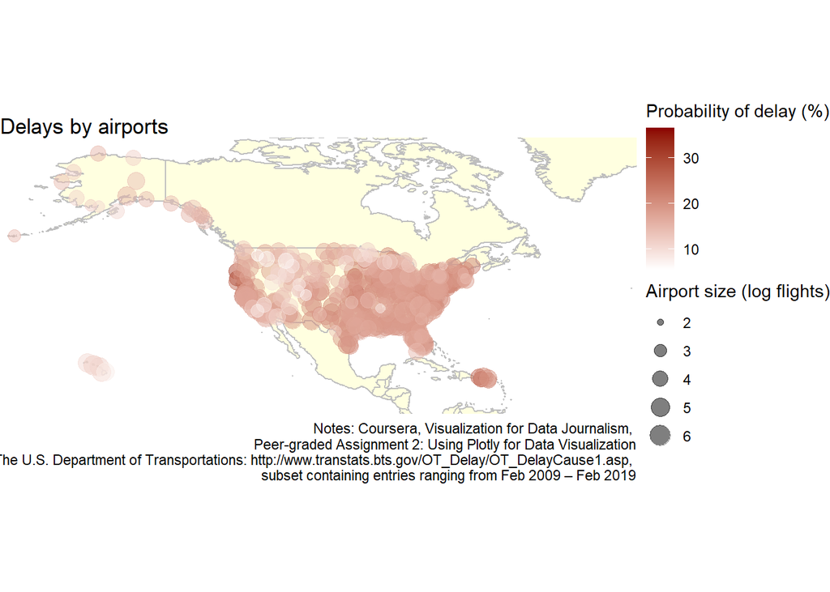